# Figure 2

- This code makes all input figures for Figure 2 of Gardner et. al. Controbution of Retrotransposition to Developmental Disorders (2018)
- All Figures need some cleaning up and processing in Illustrator
- All files/code are located in: `/Users/eg15/Documents/Current Projects/DDD/Manuscript/Figures/Figure2/`

## Startup Code

Load all libraries necessary for this notebook to work and setup basic stuff:

- libraries
- default graphpad-like theme
- function for calculating confidence intervals

## Genomic Compartment Annotation

Quick script to generate MEI files necessary for this project at : `/lustre/scratch115/projects/ddd/users/eg15/WXS_10K/VCF/VCF_v6/vep/get_annotation.sh`

- The above script will generate raw numbers for each of the genomic compartments shown in the plot
- First does an intersect to enhancers, and then removes those sites from the the subsequent file and annotates the rest of the variants
- Annotates **ALL** variants in the VCF (so not the subset used for 2b)
- All compartments are calculated independently, for the purposes of the plot I summed the following categories to make the plot cleaner:
  - UTR
    - 5’ UTR
    - 3’ UTR
  - Enhancers
    - Heart
    - Conserved
    - VISTA
- The key seen in the final figure is done completely in Illustrator, so if deleted has to be made again

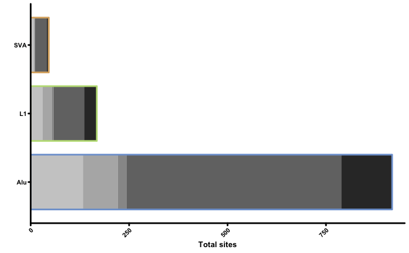

```r
comps<-c("exon","intron","UTR","enhancer","none")

##Script to generate numbers automatically @ : /lustre/scratch115/projects/ddd/users/eg15/WXS_10K/VCF/VCF_v6/vep/annotation.sh
##Numbers were then added by hand from the output
annote<-data.table(compartment=rep(comps,3),
                  count=c(128,545,23,88,133,31,78,4,24,30,4,30,0,3,8),
                  mei=c(rep("Alu",5),rep("L1",5),rep("SVA",5)))
annote[,compartment:=factor(compartment,levels=comps)]
## This just makes the coloured border around each MEI bar.
## This + 5 was based off of how the figure looks at the width I have it in the final figure. Doesn't mean anything
fake<-annote[,sum(count)+5,by=mei]
setkey(annote,compartment)
plot<-ggplot(annote,aes(mei,count,group=compartment,fill=compartment)) + geom_col(size=0,colour="black",width=0.8) + ylab("Total sites") + xlab("") + scale_fill_grey() + scale_x_discrete() + scale_y_continuous(expand=c(0,0),limits = c(0,950)) + geom_col(inherit.aes=F,data=fake,aes(mei,V1-4,colour=mei),alpha=0,size=1,width=0.8) + scale_colour_manual(values=cPalette) + theme + coord_flip()
plot
ggsave("~/Documents/Current Projects/DDD/Manuscript/Figures/Figure2/annotation.pdf",plot=plot,width=4.5,height=2.5,units="in")
```

## Generate pLI and Singleton numbers for Figure 2b

The below instructions are for filtering and generating numbers for the SNV data

Runs in 2 steps:

1. Process raw VCF files with Java code (code not here; java project QCVCF in eclipse. Raw code is at /Users/eg15/Documents/workspace/QCVCF/src/) to generate allele frequencies and QC metrics
   - Have a grid helper script that runs java on all 718 VCF file chunks located at:

   `/lustre/scratch115/projects/ddd/users/eg15/SNV_constraint/job_array.pl`
   - **note:** Change the parents file if you want unaffected/affected. There are two out directories:
     - Only have unaffected parents in the file parents_unaffected.txt and in dir out_unaffected/
     - also have ALL parents in file parents.txt and in dir out_affected/
   - **DEFAULT** is to dump all of these files in the folder out/.out. So need to make sure out folder is there and clean. **Will overwrite!**
   - VCF files list is located at:

   `/lustre/scratch115/projects/ddd/users/eg15/SNV_constraint/qc_list.txt`
   - Sample IDs are either DDD_MAIN or EGAN IDs.
     - EGAN IDs were pulled from the PSQL database and are translated in MEIAnalysisSamples_10K.xlsx
2. Run the following perl script on every out file to generate final results for SNVs: `/lustre/scratch115/projects/ddd/users/eg15/SNV_constraint/parse_results.pl`
- **note:** This script also does some bedtools magic to filter SNV sites down to the same bait regions used by the MEIs
- Bash code to run this on every file is:

```bash
ls out/* | perl -ane 'chomp $_; print "./parse_results.pl $_;\n";' | bash > results.unaffected.txt
```

The below instructions are for filtering and generating numbers for the MEI data

Quick script to generate MEI files necessary for this project at : `/lustre/scratch115/projects/ddd/users/eg15/WXS_10K/VCF/VCF_v6/vep/get_make_pLI_and_Singleton.sh`

Runs in 2 steps:

1. Extract all VEP annotation from genes with pLI information out of the VEP-annotated MEI VCFs.
   - VEP script to annotate MEIS is:

```bash
## Actual VEP script
perl -I /software/ddd/external/ensembl-vep/88/CODE/ /software/ddd/external/ensembl-vep/88/CODE/ensembl-vep-release-88/vep --force_overwrite --check_existing --offline --everything --format vcf --cache --dir /software/ddd/external/ensembl-vep/88/DATA/ --fasta /software/ddd/external/ensembl-vep/88/DATA/homo_sapiens/88_GRCh37/Homo_sapiens.GRCh37.75.dna.primary_assembly.fa --dir_plugins /software/ddd/external/ensembl-vep/PLUGINS/loftee/loftee-master --plugin LoF,human_ancestor_fa:/software/ddd/external/ensembl-vep/PLUGINS/loftee/LOF_human_ancestor/human_ancestor.fa.gz,conservation_file:/software/ddd/external/ensembl-vep/PLUGINS/loftee/phylocsf.sql -i <MEI>;.vep.vcf -o <MEI>.vep_annotated.vcf --vcf

##To run on the farm (requires at least 10Gb:
bsub -q normal -R 'select[mem<10000] rusage[mem=10000]' -M 10000 -o test.out_lsf <INSERT ABOVE>
```

2. Calculate allele frequencies seperately for exon and intron MEIs as annotated above using VCF tools like:

`vcftools --gzvcf $MEI.vep_annotated.dupes_indv_removed.vcf.gz --positions <MEI>.intron_sites.txt --out <MEI>.intron --keep parents_dddp.unaffected.txt --non-ref-ac 1 --freq` `vcftools --gzvcf $MEI.vep_annotated.dupes_indv_removed.vcf.gz --positions <MEI>.exon_sites.txt --out <MEI>.exon --keep parents_dddp.unaffected.txt --non-ref-ac 1 --freq`

This generates three sets of files:

- .pli.txt : used ONLY for pLI scores
- .exon.frq : exon allele frequencies — turned into allele counts below
- .intron.frq : intron allele frequencies — turned into allele counts below

**note** the resulting plot needs fairly extensive cleaning in AI to make the figure as shown in the manuscript. Mostly:

- Changing the “order” of the CI bars and points
- Adding in a custom figure legend
- Moving the names of the various variant categories to more readable places
- Adding lines to Nonsense and Splice site variants to connect to label

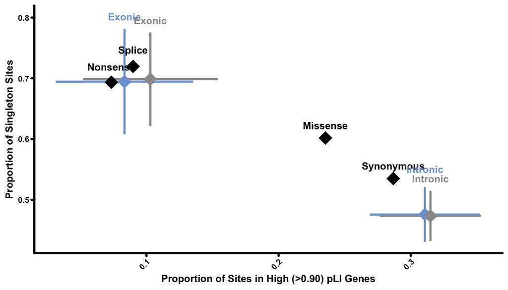